# Week1-1 slides

## Week1-1 : Introduction

## What is Machine Learning?

## What is Statistics?

## How about AI, Data Science, and Deep Learning?

[figure not shown]

"**Statistics**" means the practice or science of collecting and analyzing numerical data in large quantities.

“**Data Scientist**” means a professional who uses scientific methods to liberate and create meaning from raw data.

"**Machine learning**" is a rapidly growing field at the intersection of computer science and statistics concerned with finding patterns in data.

*It is responsible for tremendous advances in technology, from personalized product recommendations to speech recognition in cell phones. This course provides a broad introduction to the key ideas in machine learning. The emphasis will be on intuition and practical examples rather than theoretical results, though some experience with probability, statistics, and linear algebra will be important.*

[figure not shown]

[figure not shown]

#### Today's data science movement

[figure not shown]

Source: http://veronikarock.com/teaching/01_slides.pdf

#### Just for fun

[figure not shown]

#### AI-Machine Learning-Deep Learning

[figure not shown]

Source: https://levity.ai/blog/difference-machine-learning-deep-learning

#### What is Michael Jordan's opinion?

[figure not shown]

Source: https://hdsr.mitpress.mit.edu/pub/wot7mkc1/release/9

"We should embrace the fact that we are witnessing the creation of a new branch of engineering. "

"In the current era, we have a real opportunity to conceive of something historically new: a human-centric engineering discipline."

### From the 2022 Stanford AI Index Report

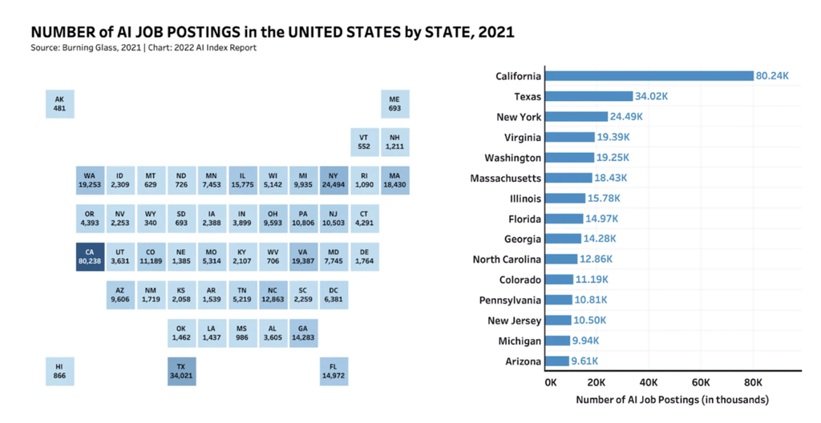

Source: https://www.economicmodeling.com/2022/03/16/where-are-the-artificial-intelligence-jobs/?fbclid=IwAR3-WY-PyuuvSHn3uuu3FSYsxGcza2BLvJ_eZ05c7wwhFg5b7--jmfrhK7g

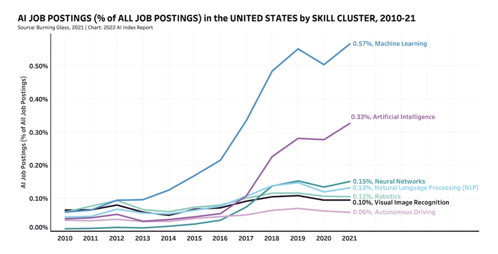

[figure not shown]

Source: https://builtin.com/artificial-intelligence

### Back to ML and Statistics

[figure not shown]

Source: https://www.stat.cmu.edu/~larry/=sml/Review.pdf